# ml_preassessment_ishva_patel

Q1.

To determine the number of multiplications and additions needed to perform a matrix multiplication between a ((n, k)) matrix (A) and a ((k, m)) matrix (B), consider the following:

- Each element in the resulting ((n, m)) matrix (C) is computed as the dot product of a row from (A) and a column from (B).
- For each element in (C), this involves (k) multiplications and (k-1) additions.

Therefore, for each of the (n * m) elements in (C):

- The total number of multiplications is (n * m * k).
- The total number of additions is (n * m * (k - 1)).

Q2

```python
#List of List Method
import time
from datetime import datetime

def matrix_multiply_list(A, B):
    n = len(A)
    k = len(A[0])
    m = len(B[0])

    C = [[0 for _ in range(m)] for _ in range(n)]

    for i in range(n):
        for j in range(m):
            for r in range(k):
                C[i][j] += A[i][r] * B[r][j]

    return C

A = [[1, 2], [3, 4], [5, 6]]
B = [[7, 8], [9, 10]]

start =  datetime.now()
C_list = matrix_multiply_list(A, B)
end =  datetime.now()
delta=end-start

print("List of Lists Time:", delta.microseconds)
print("Result using List of Lists:", C_list)
```

```
List of Lists Time: 0
Result using List of Lists: [[25, 28], [57, 64], [89, 100]]
```

```python
#numpy method
import numpy as np

def matrix_multiply_numpy(A, B):
    return np.dot(A, B)

A_np = np.array(A)
B_np = np.array(B)

start =  datetime.now()
C_np = matrix_multiply_numpy(A_np, B_np)
end =  datetime.now()
delta=end-start
print("NumPy Time:",delta.microseconds)
print("Result using NumPy:", C_np)
```

```
NumPy Time: 0
Result using NumPy: [[ 25  28]
 [ 57  64]
 [ 89 100]]
```

Q3.

```python
# Method 1: Finding median with multiple passes (O(n^2))
def find_median_naive(arr):
    n = len(arr)
    mid = n // 2
    for i in range(mid + 1):
        max_idx = 0
        for j in range(1, n):
            if arr[j] > arr[max_idx]:
                max_idx = j
        if i == mid:
            return arr[max_idx]

# Method 2: Sorting the array and finding the median (O(n log n))
def find_median_sort(arr):
    arr_sorted = sorted(arr)
    n = len(arr_sorted)
    if n % 2 == 1:
        return arr_sorted[n // 2]
    else:
        return (arr_sorted[n // 2 - 1] + arr_sorted[n // 2]) / 2

arr = np.random.randint(0, 1000000, 10000)

# Timing the naive method
arr_copy = arr.copy()
start = time.time()
median_naive = find_median_naive(arr_copy)
end = time.time()
print("Naive Method Time:", (end - start) * 1000, "ms")
print("Median (Naive):", median_naive)

# Timing the sorting method
arr_copy = arr.copy()
start = time.time()
median_sort = find_median_sort(arr_copy)
end = time.time()
print("Sorting Method Time:", (end - start) * 1000, "ms")
print("Median (Sorting):", median_sort)

# Timing the numpy median method
start = time.time()
median_numpy = np.median(arr)
end = time.time()
print("NumPy Median Time:", (end - start) * 1000, "ms")
print("Median (NumPy):", median_numpy)
```

```
Naive Method Time: 8671.40531539917 ms
Median (Naive): 999956
Sorting Method Time: 11.572837829589844 ms
Median (Sorting): 499057.5
NumPy Median Time: 2.001047134399414 ms
Median (NumPy): 499057.5
```

Q4.

The gradient of ((x ** 2)*y )+ ((y ** 3)*sin(x)) with respect to x and y is:

-The gradient with respect to x is: 2xy+((y ** 3)*cos(x))

-The gradient with respect to y is: (x ** 2) +(3*(y ** 2)*sin(x))

```python
def gradient_X(x,y):
    return (2*x*y)+((y**3)*np.cos(x))
def gradient_Y(x,y):
    return (x**2) +(3*(y**2)*np.sin(x))

x=2.0
y=3.0

g_x=gradient_X(x,y)
g_y=gradient_Y(x,y)

print(g_x,g_y)
```

```
0.7640354132271554 28.551030524293406
```

Q5.

```python
import jax
import jax.numpy as jnp

from jax import random
from jax import grad

def function(x, y):
    return (x**2 * y) + (y**3 * jnp.sin(x))

grad_x = grad(function, argnums=0)
grad_y = grad(function, argnums=1)

x_val = 2.0
y_val = 3.0

gradient_x = grad_x(x_val, y_val)
gradient_y = grad_y(x_val, y_val)

print(f"Gradient with respect to x: {gradient_x}")
print(f"Gradient with respect to y: {gradient_y}")
```

```
Gradient with respect to x: 0.7640352249145508
Gradient with respect to y: 28.551029205322266
```

Q6.

```python
import sympy as sp

x, y = sp.symbols('x y')

f = (x**2 * y) + (y**3 * sp.sin(x))

grad_x = sp.diff(f, x)
grad_y = sp.diff(f, y)

print(f"Gradient with respect to x: {grad_x}")
print(f"Gradient with respect to y: {grad_y}")

x_val = 2.0
y_val = 3.0

grad_x_value = grad_x.subs({x: x_val, y: y_val})
grad_y_value = grad_y.subs({x: x_val, y: y_val})

print(f"Gradient with respect to x at (x={x_val}, y={y_val}): {grad_x_value}")
print(f"Gradient with respect to y at (x={x_val}, y={y_val}): {grad_y_value}")
```

```
Gradient with respect to x: 2*x*y + y**3*cos(x)
Gradient with respect to y: x**2 + 3*y**2*sin(x)
Gradient with respect to x at (x=2.0, y=3.0): 0.764035413227155
Gradient with respect to y at (x=2.0, y=3.0): 28.5510305242934
```

Q7.

```python
student_records = {
    2022: {
        "Branch 1": {
            1: {
                "Name": "Alice",
                "Marks": {
                    "Maths": 100,
                    "English": 70
                }
            },
            2: {
                "Name": "Bob",
                "Marks": {
                    "Maths": 85,
                    "English": 90
                }
            }
        },
        "Branch 2": {
            1: {
                "Name": "Charlie",
                "Marks": {
                    "Maths": 88,
                    "English": 75
                }
            }
        }
    },
    2023: {
        "Branch 1": {
            1: {
                "Name": "David",
                "Marks": {
                    "Maths": 92,
                    "English": 80
                }
            }
        },
        "Branch 2": {
            1: {
                "Name": "Eva",
                "Marks": {
                    "Maths": 76,
                    "English": 85
                }
            }
        }
    },
    2024: {
        "Branch 1": {
            1: {
                "Name": "Frank",
                "Marks": {
                    "Maths": 91,
                    "English": 77
                }
            }
        },
        "Branch 2": {
            1: {
                "Name": "Grace",
                "Marks": {
                    "Maths": 89,
                    "English": 82
                }
            }
        }
    },
    2025: {
        "Branch 1": {
            1: {
                "Name": "Hannah",
                "Marks": {
                    "Maths": 94,
                    "English": 78
                }
            }
        },
        "Branch 2": {
            1: {
                "Name": "Ian",
                "Marks": {
                    "Maths": 82,
                    "English": 88
                }
            }
        }
    }
}

student_records
```

```
{2022: {'Branch 1': {1: {'Name': 'Alice',
    'Marks': {'Maths': 100, 'English': 70}},
   2: {'Name': 'Bob', 'Marks': {'Maths': 85, 'English': 90}}},
  'Branch 2': {1: {'Name': 'Charlie', 'Marks': {'Maths': 88, 'English': 75}}}},
 2023: {'Branch 1': {1: {'Name': 'David',
    'Marks': {'Maths': 92, 'English': 80}}},
  'Branch 2': {1: {'Name': 'Eva', 'Marks': {'Maths': 76, 'English': 85}}}},
 2024: {'Branch 1': {1: {'Name': 'Frank',
    'Marks': {'Maths': 91, 'English': 77}}},
  'Branch 2': {1: {'Name': 'Grace', 'Marks': {'Maths': 89, 'English': 82}}}},
 2025: {'Branch 1': {1: {'Name': 'Hannah',
    'Marks': {'Maths': 94, 'English': 78}}},
  'Branch 2': {1: {'Name': 'Ian', 'Marks': {'Maths': 82, 'English': 88}}}}}
```

Q8.

```python
class Student:
    def __init__(self, roll_number, name, marks):
        self.roll_number = roll_number
        self.name = name
        self.marks = marks

class Branch:
    def __init__(self, name):
        self.name = name
        self.students = []

    def add_student(self, student):
        self.students.append(student)

class Year:
    def __init__(self, year):
        self.year = year
        self.branches = []

    def add_branch(self, branch):
        self.branches.append(branch)

class Database:
    def __init__(self):
        self.years = []

    def add_year(self, year):
        self.years.append(year)


db = Database()

year_2022 = Year(2022)
year_2023 = Year(2023)

branch1_2022 = Branch("Branch 1")
branch2_2022 = Branch("Branch 2")

branch1_2023 = Branch("Branch 1")
branch2_2023 = Branch("Branch 2")

student1 = Student(1, "Alice", {"Maths": 100, "English": 70})
student2 = Student(2, "Bob", {"Maths": 90, "English": 80})

branch1_2022.add_student(student1)
branch2_2022.add_student(student2)

branch1_2023.add_student(student1)
branch2_2023.add_student(student2)

year_2022.add_branch(branch1_2022)
year_2022.add_branch(branch2_2022)

year_2023.add_branch(branch1_2023)
year_2023.add_branch(branch2_2023)

db.add_year(year_2022)
db.add_year(year_2023)

def print_database(db):
    for year in db.years:
        print(f"Year: {year.year}")
        for branch in year.branches:
            print(f"  Branch: {branch.name}")
            for student in branch.students:
                print(f"    Roll Number: {student.roll_number}, Name: {student.name}, Marks: {student.marks}")

print_database(db)
```

```
Year: 2022
  Branch: Branch 1
    Roll Number: 1, Name: Alice, Marks: {'Maths': 100, 'English': 70}
  Branch: Branch 2
    Roll Number: 2, Name: Bob, Marks: {'Maths': 90, 'English': 80}
Year: 2023
  Branch: Branch 1
    Roll Number: 1, Name: Alice, Marks: {'Maths': 100, 'English': 70}
  Branch: Branch 2
    Roll Number: 2, Name: Bob, Marks: {'Maths': 90, 'English': 80}
```

Q9.

```python
import matplotlib.pyplot as plt
x=np.arange(0.5,100.5,0.5)
```

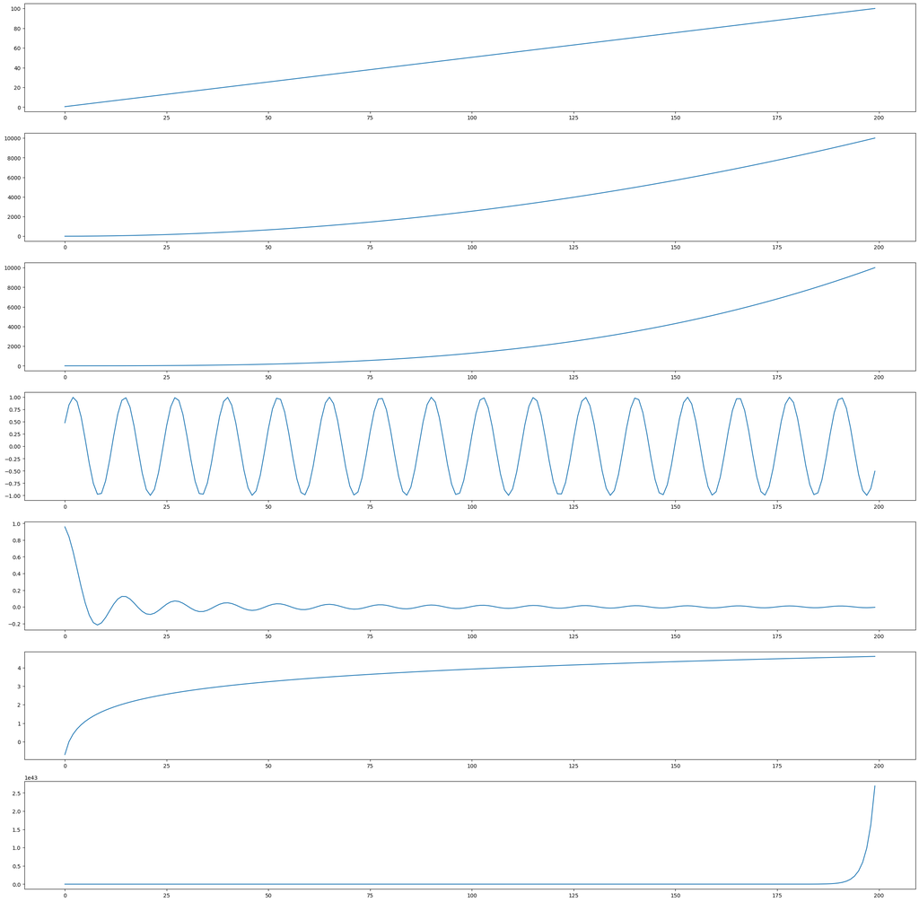

```python
fig,ax=plt.subplots(7,1,figsize=(30,30))
ax[0].plot(x)
ax[1].plot(x**2)
ax[2].plot((x**3)/100)
ax[3].plot(np.sin(x))
ax[4].plot(np.sin(x)/x)
ax[5].plot(np.log(x))
ax[6].plot(np.exp(x))
```

Q10.

```python
rows, cols = 20, 5
matrix = np.random.uniform(low=1.0, high=2.0, size=(rows, cols))

print(matrix)
```

```
[[1.30331893 1.3746013  1.45793018 1.42546768 1.93683812]
 [1.65936796 1.27714787 1.49700424 1.55084109 1.48031901]
 [1.11515264 1.73829021 1.85470037 1.37665882 1.69023782]
 [1.59446414 1.75371017 1.16090671 1.93828871 1.71913862]
 [1.45406009 1.14733241 1.43194219 1.38096824 1.58134468]
 [1.22106424 1.01321026 1.58324191 1.08130719 1.18697272]
 [1.79016526 1.21507953 1.07945317 1.64565047 1.76131668]
 [1.60152467 1.70134243 1.62363521 1.52700249 1.37048243]
 [1.92466572 1.69907822 1.68938414 1.93785741 1.67327294]
 [1.77247531 1.47218629 1.46163392 1.84143152 1.46855564]
 [1.66503145 1.78938939 1.52161784 1.42218295 1.86295569]
 [1.98237507 1.28995765 1.72414433 1.25018975 1.0400994 ]
 [1.07502733 1.48820266 1.1030578  1.56846716 1.56532612]
 [1.24711827 1.73738624 1.72276488 1.33229376 1.43474419]
 [1.93105006 1.02478265 1.05328948 1.91855704 1.76499429]
 [1.22824348 1.68356501 1.23956824 1.11877273 1.19860782]
 [1.52325713 1.74519383 1.62423415 1.49180465 1.95541946]
 [1.61231555 1.76073219 1.28826806 1.25051401 1.02445401]
 [1.52457037 1.670406   1.98031992 1.0264432  1.15871018]
 [1.19446656 1.38724591 1.60792149 1.1767516  1.96613275]]
```

```python
import pandas as pd

df=pd.DataFrame(matrix,columns=['A','B','C','D','E'])
```

```python
df.describe()
```

|  | A | B | C | D | E |
| --- | --- | --- | --- | --- | --- |
| count | 20.000000 | 20.000000 | 20.000000 | 20.000000 | 20.000000 |
| mean | 1.520986 | 1.498442 | 1.485251 | 1.463073 | 1.541996 |
| std | 0.282148 | 0.263947 | 0.262293 | 0.282912 | 0.302704 |
| min | 1.075027 | 1.013210 | 1.053289 | 1.026443 | 1.024454 |
| 25% | 1.242400 | 1.286755 | 1.276093 | 1.250433 | 1.327514 |
| 50% | 1.559517 | 1.579304 | 1.509311 | 1.423825 | 1.573335 |
| 75% | 1.691892 | 1.737612 | 1.640522 | 1.587763 | 1.762236 |
| max | 1.982375 | 1.789389 | 1.980320 | 1.938289 | 1.966133 |

```python
col_with_highest_std = df.std().idxmax()
highest_std_value = df.std().max()
print(col_with_highest_std ,highest_std_value)

row_with_lowest_mean = df.mean(axis=1).idxmin()
lowest_mean_value = df.mean(axis=1).min()
print(row_with_lowest_mean,lowest_mean_value)
```

```
E 0.302704463620396
5 1.2171592620443934
```

Q11.

```python
df.sum(axis=1)
```

```
0     7.498156
1     7.464680
2     7.775040
3     8.166508
4     6.995648
5     6.085796
6     7.491665
7     7.823987
8     8.924258
9     8.016283
10    8.261177
11    7.286766
12    6.800081
13    7.474307
14    7.692674
15    6.468757
16    8.339909
17    6.936284
18    7.360450
19    7.332518
dtype: float64
```

```python
df['F']=df.sum(axis=1)
```

```python
df
```

|  | A | B | C | D | E | F |
| --- | --- | --- | --- | --- | --- | --- |
| 0 | 1.303319 | 1.374601 | 1.457930 | 1.425468 | 1.936838 | 7.498156 |
| 1 | 1.659368 | 1.277148 | 1.497004 | 1.550841 | 1.480319 | 7.464680 |
| 2 | 1.115153 | 1.738290 | 1.854700 | 1.376659 | 1.690238 | 7.775040 |
| 3 | 1.594464 | 1.753710 | 1.160907 | 1.938289 | 1.719139 | 8.166508 |
| 4 | 1.454060 | 1.147332 | 1.431942 | 1.380968 | 1.581345 | 6.995648 |
| 5 | 1.221064 | 1.013210 | 1.583242 | 1.081307 | 1.186973 | 6.085796 |
| 6 | 1.790165 | 1.215080 | 1.079453 | 1.645650 | 1.761317 | 7.491665 |
| 7 | 1.601525 | 1.701342 | 1.623635 | 1.527002 | 1.370482 | 7.823987 |
| 8 | 1.924666 | 1.699078 | 1.689384 | 1.937857 | 1.673273 | 8.924258 |
| 9 | 1.772475 | 1.472186 | 1.461634 | 1.841432 | 1.468556 | 8.016283 |
| 10 | 1.665031 | 1.789389 | 1.521618 | 1.422183 | 1.862956 | 8.261177 |
| 11 | 1.982375 | 1.289958 | 1.724144 | 1.250190 | 1.040099 | 7.286766 |
| 12 | 1.075027 | 1.488203 | 1.103058 | 1.568467 | 1.565326 | 6.800081 |
| 13 | 1.247118 | 1.737386 | 1.722765 | 1.332294 | 1.434744 | 7.474307 |
| 14 | 1.931050 | 1.024783 | 1.053289 | 1.918557 | 1.764994 | 7.692674 |
| 15 | 1.228243 | 1.683565 | 1.239568 | 1.118773 | 1.198608 | 6.468757 |
| 16 | 1.523257 | 1.745194 | 1.624234 | 1.491805 | 1.955419 | 8.339909 |
| 17 | 1.612316 | 1.760732 | 1.288268 | 1.250514 | 1.024454 | 6.936284 |
| 18 | 1.524570 | 1.670406 | 1.980320 | 1.026443 | 1.158710 | 7.360450 |
| 19 | 1.194467 | 1.387246 | 1.607921 | 1.176752 | 1.966133 | 7.332518 |

```python
df['G'] = df['F'].apply(lambda x: 'LT-8' if x < 8 else 'GT-8')
```

```python
df
```

|  | A | B | C | D | E | F | G |
| --- | --- | --- | --- | --- | --- | --- | --- |
| 0 | 1.303319 | 1.374601 | 1.457930 | 1.425468 | 1.936838 | 7.498156 | LT-8 |
| 1 | 1.659368 | 1.277148 | 1.497004 | 1.550841 | 1.480319 | 7.464680 | LT-8 |
| 2 | 1.115153 | 1.738290 | 1.854700 | 1.376659 | 1.690238 | 7.775040 | LT-8 |
| 3 | 1.594464 | 1.753710 | 1.160907 | 1.938289 | 1.719139 | 8.166508 | GT-8 |
| 4 | 1.454060 | 1.147332 | 1.431942 | 1.380968 | 1.581345 | 6.995648 | LT-8 |
| 5 | 1.221064 | 1.013210 | 1.583242 | 1.081307 | 1.186973 | 6.085796 | LT-8 |
| 6 | 1.790165 | 1.215080 | 1.079453 | 1.645650 | 1.761317 | 7.491665 | LT-8 |
| 7 | 1.601525 | 1.701342 | 1.623635 | 1.527002 | 1.370482 | 7.823987 | LT-8 |
| 8 | 1.924666 | 1.699078 | 1.689384 | 1.937857 | 1.673273 | 8.924258 | GT-8 |
| 9 | 1.772475 | 1.472186 | 1.461634 | 1.841432 | 1.468556 | 8.016283 | GT-8 |
| 10 | 1.665031 | 1.789389 | 1.521618 | 1.422183 | 1.862956 | 8.261177 | GT-8 |
| 11 | 1.982375 | 1.289958 | 1.724144 | 1.250190 | 1.040099 | 7.286766 | LT-8 |
| 12 | 1.075027 | 1.488203 | 1.103058 | 1.568467 | 1.565326 | 6.800081 | LT-8 |
| 13 | 1.247118 | 1.737386 | 1.722765 | 1.332294 | 1.434744 | 7.474307 | LT-8 |
| 14 | 1.931050 | 1.024783 | 1.053289 | 1.918557 | 1.764994 | 7.692674 | LT-8 |
| 15 | 1.228243 | 1.683565 | 1.239568 | 1.118773 | 1.198608 | 6.468757 | LT-8 |
| 16 | 1.523257 | 1.745194 | 1.624234 | 1.491805 | 1.955419 | 8.339909 | GT-8 |
| 17 | 1.612316 | 1.760732 | 1.288268 | 1.250514 | 1.024454 | 6.936284 | LT-8 |
| 18 | 1.524570 | 1.670406 | 1.980320 | 1.026443 | 1.158710 | 7.360450 | LT-8 |
| 19 | 1.194467 | 1.387246 | 1.607921 | 1.176752 | 1.966133 | 7.332518 | LT-8 |

```python
df[df['G']=='LT-8']['F'].std()
```

```
0.4902233855732082
```

```python
df[df['G']=='GT-8']['F'].std()
```

```
0.34729308773041323
```

Q12. Broadcasting is a powerful mechanism in NumPy that allows operations on arrays of different shapes. It avoids making unnecessary copies of data and allows vectorized operations, which makes computations faster and more memory efficient. Here's a small example to explain broadcasting: Suppose we have a 2D array (matrix) and we want to add a 1D array (vector) to each row of the matrix. Normally, we'd have to duplicate the vector to match the shape of the matrix. With broadcasting, NumPy automatically handles this for us.

```python
import numpy as np

# Create a 2D array (3x3 matrix)
matrix = np.array([[1, 2, 3],
                   [4, 5, 6],
                   [7, 8, 9]])

# Create a 1D array (vector)
vector = np.array([10, 20, 30])

# Add the vector to each row of the matrix using broadcasting
result = matrix + vector

print("Matrix:\n", matrix)
print("Vector:\n", vector)
print("Result:\n", result)
```

```
Matrix:
 [[1 2 3]
 [4 5 6]
 [7 8 9]]
Vector:
 [10 20 30]
Result:
 [[11 22 33]
 [14 25 36]
 [17 28 39]]
```

Q13.

```python
def argmin(arr):
    mini=arr[0]
    ind=0

    for i in range(len(arr)):
        if arr[i]<mini:
            mini=arr[i]
            ind=i
    return ind;

arr=np.array([78,99,6,60,55,7,8,9,3,4,67])

index=argmin(arr)
index1=np.argmin(arr)

print(index,index1)
```

```
8 8
```